# Jeux Olimpiques

Safarishvili Irina

02 11 2021

[figure not shown]

Il s’agit d’un ensemble de données historiques sur les Jeux Olympiques y compris ceux-ci modernes, incluant tous les Jeux d’Athènes 1896 à Rio 2016. Il faut noter que les Jeux d’hiver et d’été ont eu lieu la même année jusqu’en 1992. Après cela, ils les ont échelonnés de sorte que les Jeux d’hiver se déroulent sur un cycle de quatre ans à partir de 1994, puis d’été en 1996, puis d’hiver en 1998, et ainsi de suite. .

Questions:

**1) Quel est l’age de participant max et min pendent toute l’histoire de Jeux Olympiques?**

```r
summary(olympics) %>%
  kbl() %>%
  kable_styling()
```

|  | id | name | sex | age | height | weight | team | noc | games | year | season | city | sport | event | medal |
| --- | --- | --- | --- | --- | --- | --- | --- | --- | --- | --- | --- | --- | --- | --- | --- |
|  | Min. : 1 | Length:271116 | Length:271116 | Min. :10.00 | Min. :127.0 | Min. : 25.0 | Length:271116 | Length:271116 | Length:271116 | Min. :1896 | Length:271116 | Length:271116 | Length:271116 | Length:271116 | Length:271116 |
|  | 1st Qu.: 34643 | Class :character | Class :character | 1st Qu.:21.00 | 1st Qu.:168.0 | 1st Qu.: 60.0 | Class :character | Class :character | Class :character | 1st Qu.:1960 | Class :character | Class :character | Class :character | Class :character | Class :character |
|  | Median : 68205 | Mode :character | Mode :character | Median :24.00 | Median :175.0 | Median : 70.0 | Mode :character | Mode :character | Mode :character | Median :1988 | Mode :character | Mode :character | Mode :character | Mode :character | Mode :character |
|  | Mean : 68249 | NA | NA | Mean :25.56 | Mean :175.3 | Mean : 70.7 | NA | NA | NA | Mean :1978 | NA | NA | NA | NA | NA |
|  | 3rd Qu.:102097 | NA | NA | 3rd Qu.:28.00 | 3rd Qu.:183.0 | 3rd Qu.: 79.0 | NA | NA | NA | 3rd Qu.:2002 | NA | NA | NA | NA | NA |
|  | Max. :135571 | NA | NA | Max. :97.00 | Max. :226.0 | Max. :214.0 | NA | NA | NA | Max. :2016 | NA | NA | NA | NA | NA |
|  | NA | NA | NA | NA’s :9474 | NA’s :60171 | NA’s :62875 | NA | NA | NA | NA | NA | NA | NA | NA | NA |

```r
olympics %>%
  select(name, age, year, medal, team, sport, event) %>%
  filter(age==10 | age==97) %>%
  kbl() %>%
  kable_styling()
```

| name | age | year | medal | team | sport | event |
| --- | --- | --- | --- | --- | --- | --- |
| Dimitrios Loundras | 10 | 1896 | Bronze | Ethnikos Gymnastikos Syllogos | Gymnastics | Gymnastics Men’s Parallel Bars, Teams |
| John Quincy Adams Ward | 97 | 1928 | NA | United States | Art Competitions | Art Competitions Mixed Sculpturing, Statues |

**2) Combien de femmes et d’hommes ont participé dans toute l’histoire des Jeux Olympiques?**

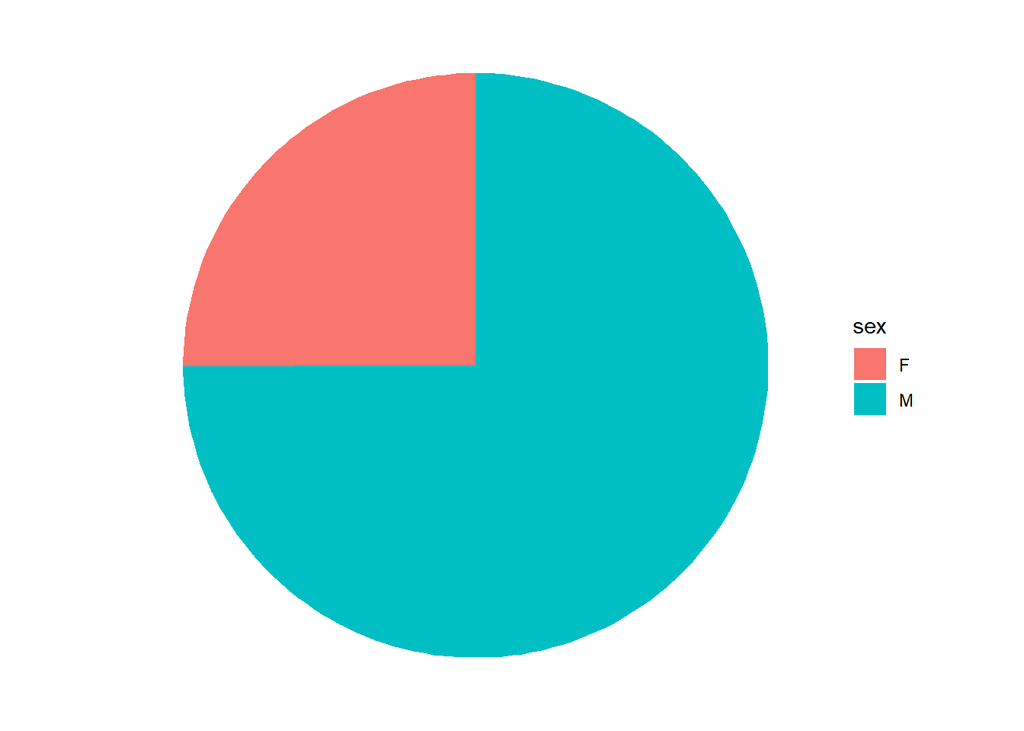

```r
olympics %>%
  select(id, sex) %>%
  distinct() %>%
  group_by(sex) %>%
  summarise(N=n()) %>%
ggplot(aes(x="",N, fill=sex))+geom_bar(stat = "identity")+coord_polar("y",start=0)+ theme_void()
```

**3) Quel est pourcentage d’hommes parmi les gagnants?**

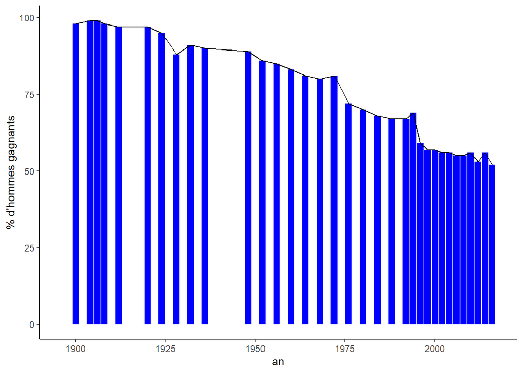

```r
  olympics %>%
  select( year,id, sex, medal) %>%
  drop_na(medal) %>%
  distinct() %>%
  group_by(year, sex) %>%
  summarise(N=n()) %>%
  pivot_wider(names_from = sex,values_from = N) %>%
  mutate(Part_M=round(M/(F+M),2)*100, Part_F=F/(F+M)) %>%
  ggplot(aes(x=year, y=Part_M))+geom_col(fill="blue")+geom_line() +theme_classic()+labs(y= "% d'hommes gagnants", x="an")
```

**4)Est-ce que le nombre de femmes a augmenté?**

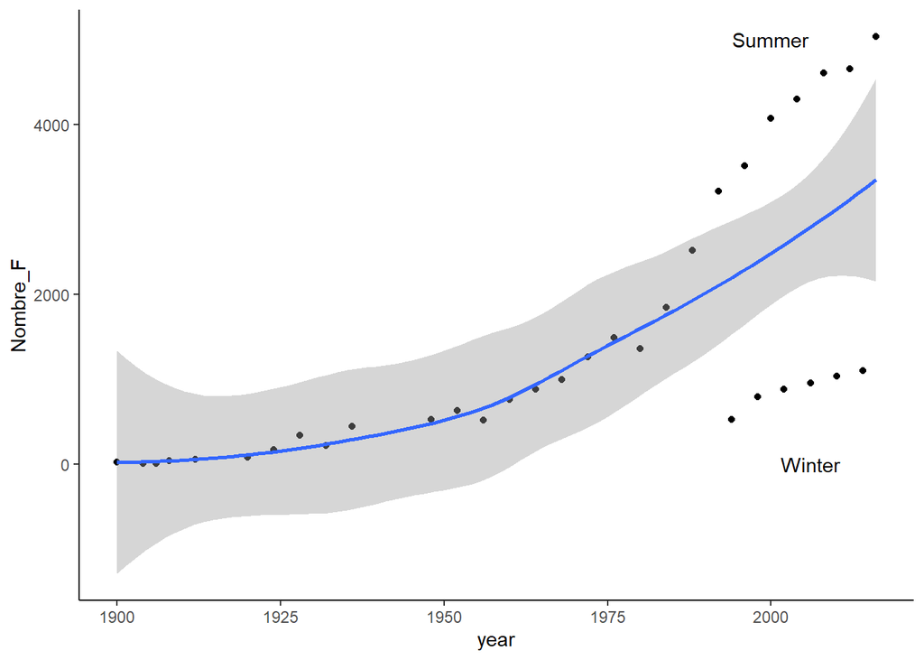

[output not shown]

```r
olympics %>%
  select(id, sex, year) %>%
  distinct() %>%
  filter(sex=="F") %>%
  group_by(year) %>%
  summarise(Nombre_F=n()) %>%
  ggplot(aes(year,Nombre_F))+geom_point()+geom_smooth()+annotate(geom="text", label="Winter", x=2006, y=0 )+annotate(geom="text", label="Summer", x=2000, y=5000 )+theme_classic()
```

**5)Quel est l’age moyenne de gagnants parmi les femmes et les hommes?**

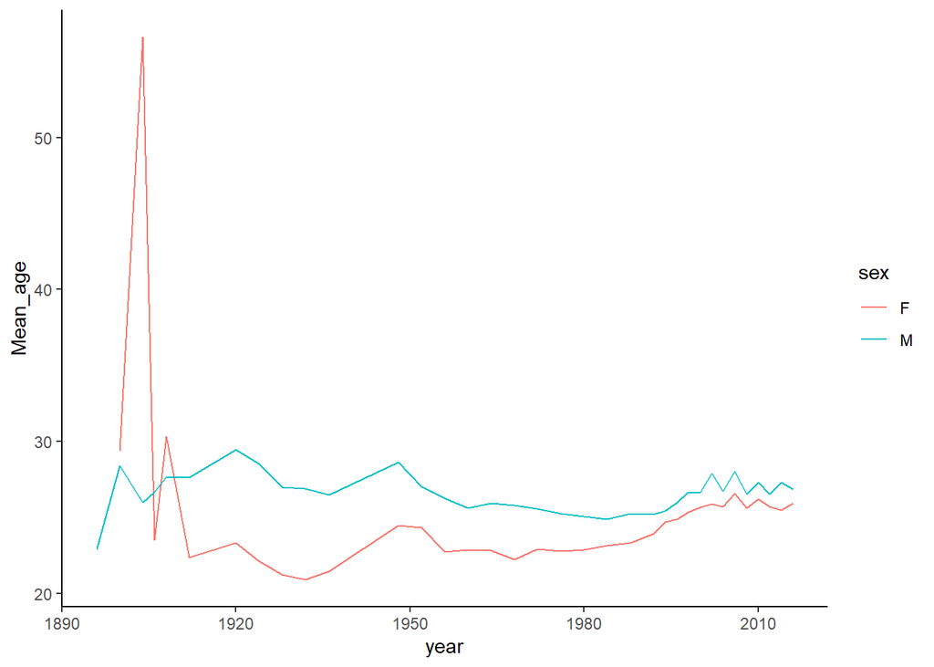

```r
olympics %>%
  select(id, sex,age, medal, year) %>%
  drop_na(medal) %>%
  distinct() %>%
  group_by(year, sex) %>%
  summarise(Mean_age=mean(age, na.rm = TRUE)) %>%
  ggplot(aes(year,Mean_age, fill=sex))+geom_line(aes(color=sex))+theme_classic()
```

**6) Quel pays a gagné plus de medales olympiques?**

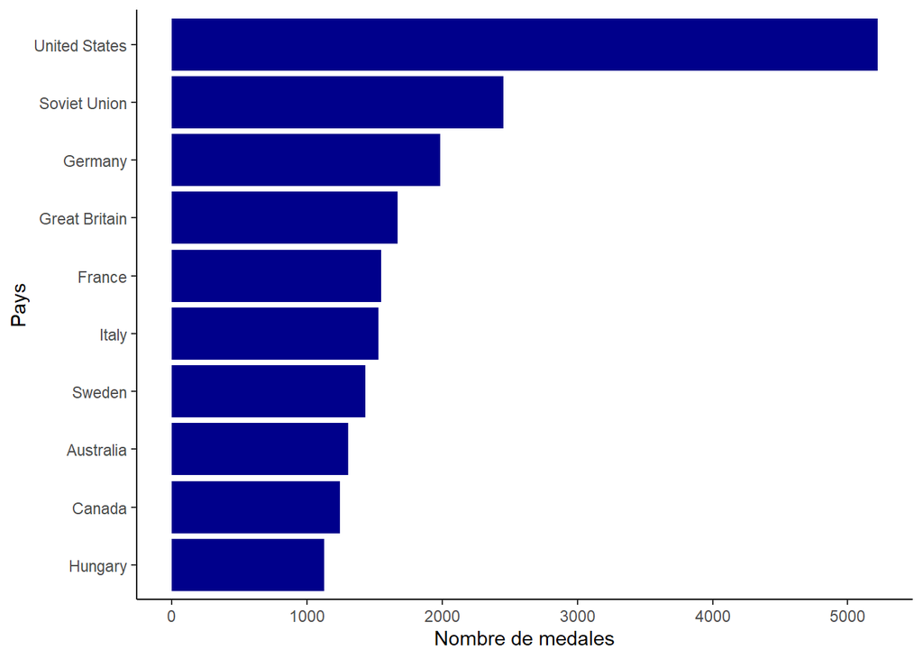

```r
olympics %>%
  select(team, medal) %>%
  drop_na(medal) %>%
  group_by(team) %>%
  summarise(Nb_m=n()) %>%
  arrange(-Nb_m) %>%
  top_n(10)%>%
  ggplot(aes(reorder(team, Nb_m),Nb_m, ) )+geom_col(fill="dark blue")+coord_flip()+theme_classic()+labs(x= "Pays", y="Nombre de medales")
```

**7) Combien de type de sport est représenté dans cette base de donnée?**

```r
olympics %>%
  select(sport, season) %>%
  distinct() %>%
  group_by(season) %>%
  arrange(season) %>%
  summarise(N=n()) %>%
  kbl() %>%
  kable_styling()
```

| season | N |
| --- | --- |
| Summer | 52 |
| Winter | 17 |

**8) Est-que le nombre de type de sport a augmenté au fil du temps?**

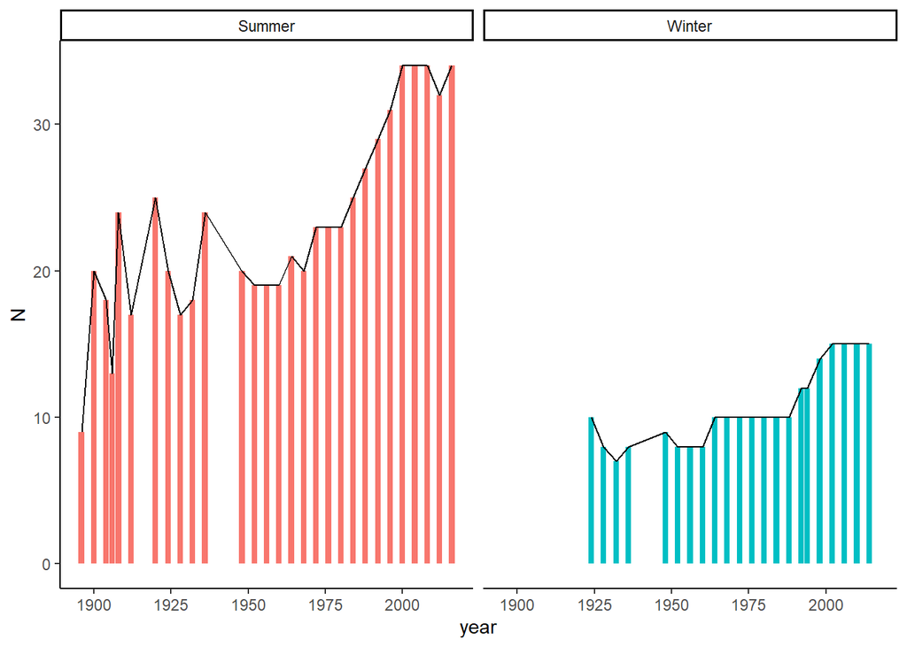

```r
olympics %>%
  select(sport, season, year) %>%
  distinct() %>%
  group_by(year,season) %>%
  summarise(N=n()) %>%
  arrange(year) %>%
  ggplot(aes(year,N, fill=season))+geom_col()+facet_wrap(~season)+geom_line()+theme_classic()+theme(legend.position ="none")
```

**9)Quel sont les sports les plus populaires en France et en Russie?**

```r
olympics %>%
  select(team, season, sport, year)%>%
  filter(year>1980 & team=="France"|team=="Russia") %>%
  group_by(team, season,sport ) %>%
  summarise(N=n()) %>%
  arrange(-N) %>%
  top_n(3) %>%
  pivot_wider(names_from = team, values_from = N)%>%
  kbl() %>%
  kable_styling()
```

| season | sport | Russia | France |
| --- | --- | --- | --- |
| Summer | Athletics | 604 | 528 |
| Summer | Gymnastics | 408 | 569 |
| Summer | Swimming | 381 | 453 |
| Winter | Alpine Skiing | NA | 274 |
| Winter | Cross Country Skiing | 255 | 239 |
| Winter | Biathlon | NA | 239 |
| Winter | Ice Hockey | 215 | NA |
| Winter | Speed Skating | 202 | NA |

**10) Quel est un profil de gagnant dans athlétique, gymnastique et ski de fond en France et en Russie?**

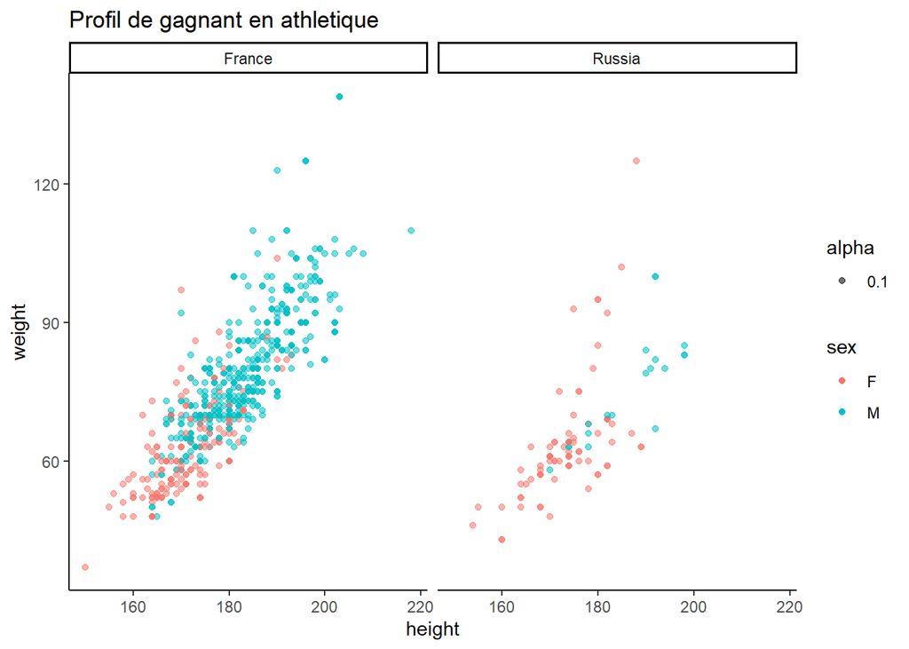

```r
olympics %>%
  select(sport, sex, age, height, weight, medal, year, team) %>%
  filter(year>1980 & team=="France"|team=="Russia"  & sport=="Athletics") %>%
  drop_na(medal, height, weight) %>%
  ggplot(aes(height,weight))+geom_point(aes(color=sex,  alpha=0.1))+facet_wrap(~team)+theme_classic()+labs(title = "Profil de gagnant en athlétique")
```

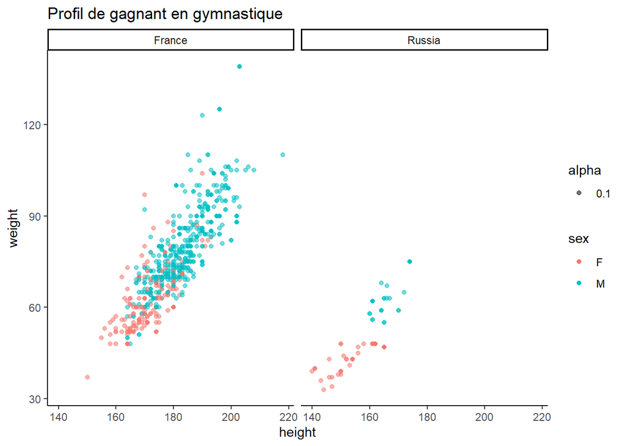

```r
olympics %>%
  select(sport, sex, age, height, weight, medal, year, team) %>%
  filter(year>1980 & team=="France"|team=="Russia"  & sport=="Gymnastics") %>%
  drop_na(medal, height, weight) %>%
  ggplot(aes(height,weight))+geom_point(aes(color=sex, alpha=0.1))+facet_wrap(~team)+theme_classic()+labs(title = "Profil de gagnant en gymnastique")
```

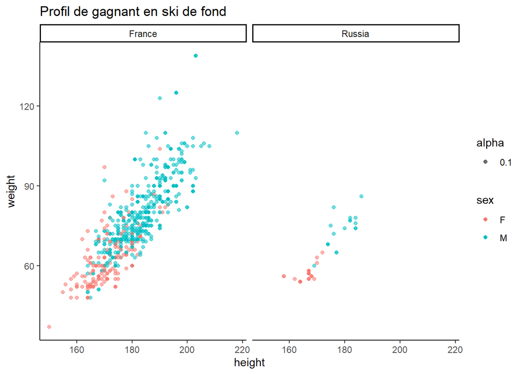

```r
olympics %>%
  select(sport, sex, age, height, weight, medal, year, team) %>%
  filter(year>1980 & team=="France"|team=="Russia"  & sport=="Cross Country Skiing") %>%
  drop_na(medal, height, weight) %>%
  ggplot(aes(height,weight))+geom_point(aes(color=sex, alpha=0.1))+facet_wrap(~team)+theme_classic()+labs(title = "Profil de gagnant en ski de fond")
```

**11) De quoi dépendent les chances de gagner dans athlétique, gymnastique et ski de fond ?**

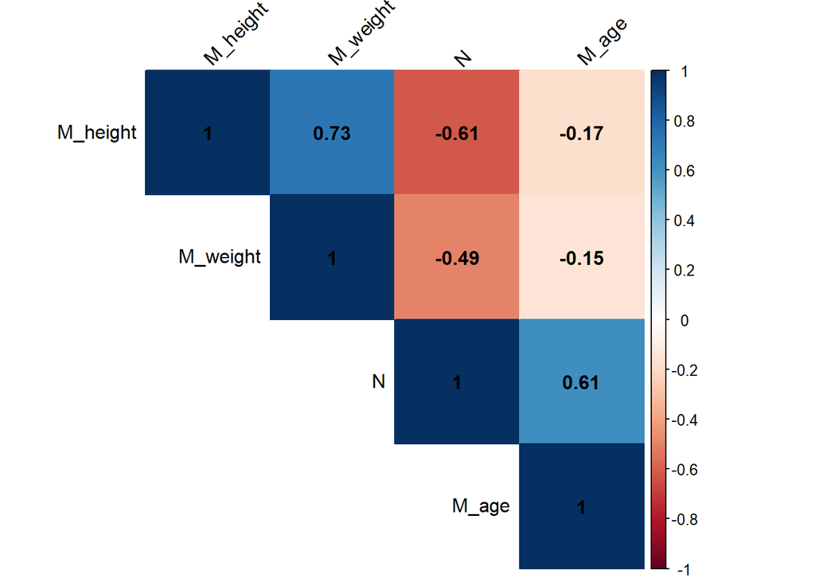

```r
ol1 <-olympics %>%
  select(year, sport, medal, age, height, weight) %>%
  filter(sport=="Athletics") %>%
  drop_na(age, height, weight, medal) %>%
  group_by(year) %>%
  arrange(year) %>%
  summarise(N=n(), M_age=mean(age), M_height=mean(height), M_weight=mean(weight))

ol1 %>%
  select(-year) %>%
  cor() %>%
  corrplot( method="color",type = "upper", order = "hclust", addCoef.col = "black",
         tl.col = "black", tl.srt = 45)
```

```r
ol1 %>%
lm(N ~ M_age +M_height+M_weight, data=.) %>%
  coef() %>%
  tidy()
```

```
## # A tibble: 4 x 2
##   names             x
##   <chr>         <dbl>
## 1 (Intercept) 3724.
## 2 M_age         24.6
## 3 M_height     -22.7
## 4 M_weight      -2.41
```

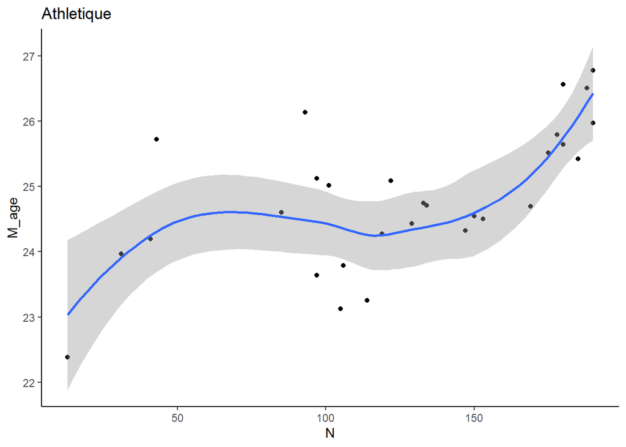

```r
ol1 %>%
lm(N ~ M_age +M_height+M_weight, data=.) %>%
  augment() %>%
  ggplot(aes(N,M_age))+geom_point()+geom_smooth()+theme_classic()+labs(title = "Athlétique")
```

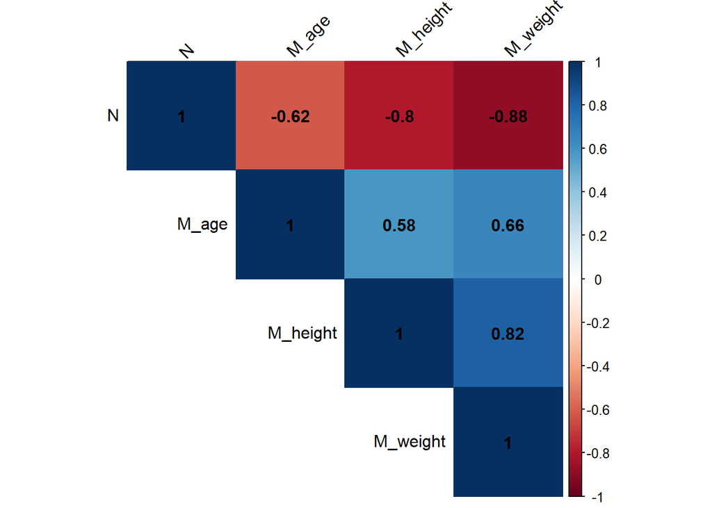

```r
ol2 <-olympics %>%
  select(year, sport, medal, age, height, weight) %>%
  filter(sport=="Gymnastics") %>%
  drop_na(age, height, weight, medal) %>%
  group_by(year) %>%
  arrange(year) %>%
  summarise(N=n(), M_age=mean(age), M_height=mean(height), M_weight=mean(weight))

ol2 %>%
  select(-year) %>%
  cor() %>%
  corrplot( method="color",type = "upper", order = "hclust", addCoef.col = "black",
         tl.col = "black", tl.srt = 45)
```

```r
ol2 %>%
lm(N ~ M_age +M_height+M_weight, data=.) %>%
  coef() %>%
  tidy()
```

```
## # A tibble: 4 x 2
##   names             x
##   <chr>         <dbl>
## 1 (Intercept) 494.
## 2 M_age        -0.554
## 3 M_height     -1.44
## 4 M_weight     -3.39
```

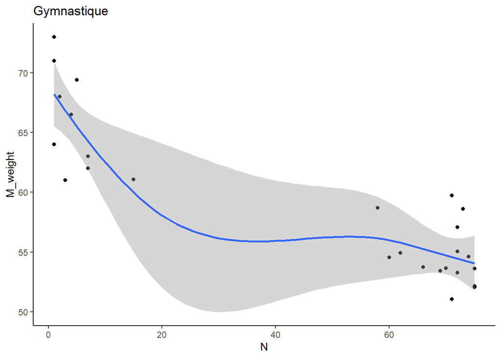

```r
ol2 %>%
lm(N ~ M_age +M_height+M_weight, data=.) %>%
  augment() %>%
  ggplot(aes(N,M_weight))+geom_point()+geom_smooth()+theme_classic()+labs(title = "Gymnastique")
```

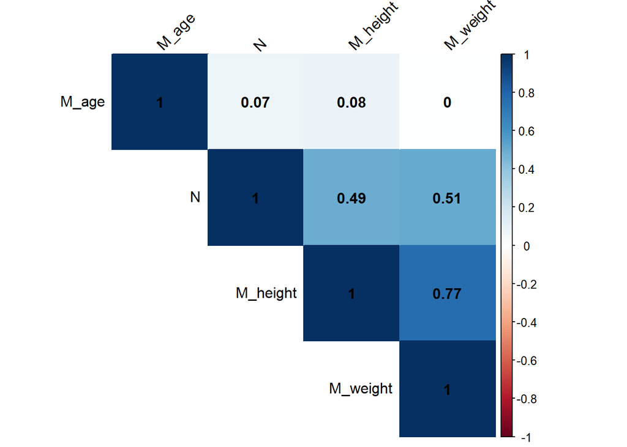

```r
ol3 <-olympics %>%
  select(year, sport, medal, age, height, weight) %>%
  filter(sport=="Cross Country Skiing") %>%
  drop_na(age, height, weight, medal) %>%
  group_by(year) %>%
  arrange(year) %>%
  summarise(N=n(), M_age=mean(age), M_height=mean(height), M_weight=mean(weight))

ol3 %>%
  select(-year) %>%
  cor() %>%
  corrplot( method="color",type = "upper", order = "hclust", addCoef.col = "black",
         tl.col = "black", tl.srt = 45)
```

```r
ol3 %>%
lm(N ~ M_age +M_height+M_weight, data=.) %>%
  coef() %>%
  tidy()
```

```
## # A tibble: 4 x 2
##   names              x
##   <chr>          <dbl>
## 1 (Intercept) -587.
## 2 M_age          0.823
## 3 M_height       1.90
## 4 M_weight       4.11
```

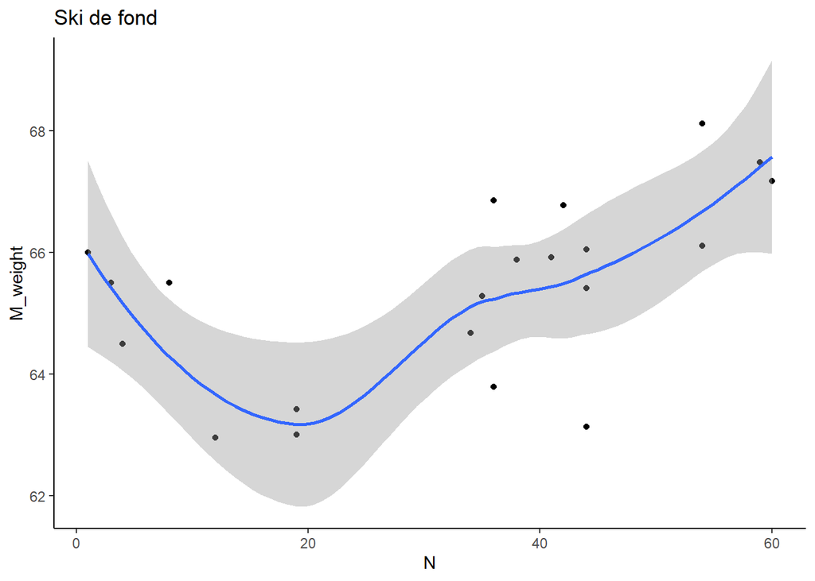

```r
ol3 %>%
lm(N ~ M_age +M_height+M_weight, data=.) %>%
  augment() %>%
  ggplot(aes(N,M_weight))+geom_point()+geom_smooth()+theme_classic()+labs(title = "Ski de fond")
```